# Meteoritos que cayeron a la Tierra

**Herramientas de Programación con Python · 2026-2**

Richard Michel Altamirano Galvez · Gabriel Andreas Saco Alvarado · Fina Rosmery Pretil Pocomucha

Análisis exploratorio de los registros del catálogo entregado por el profesor. Estudiamos ubicación, tipo de registro, año, clase y masa, con un caso sobre el Perú. El objetivo es describir el catálogo y sus limitaciones, no estimar la probabilidad de impacto.

## Cómo ejecutar

Abra este notebook dentro de `entrega_meteoritos` y seleccione **Reiniciar kernel y ejecutar todas las celdas**. También se puede ejecutar desde la raíz del repositorio. Se necesitan pandas, NumPy, Matplotlib, Cartopy, Shapely y openpyxl (ver `requirements.txt`). No requiere internet: los datos y las fronteras están incluidos. En Colab, suba y descomprima la carpeta completa y cambie el directorio a `entrega_meteoritos`.

El notebook genera diez gráficos PNG y PDF, un CSV preparado y un Excel con varias hojas en `resultados`. Los archivos se regeneran al ejecutarlo. Las contribuciones anteriores del grupo no son entradas de este análisis.

## 1. Objetivo, fuentes y criterios

La unidad de observación es **un registro identificado por `id`**, no necesariamente un impacto independiente. Se conserva la clasificación original, incluido `name_type = Relict`, sin reclasificar casos por intuición.

- Fuente principal: CSV y diccionario entregados. [TidyTuesday, 11 de junio de 2019](https://github.com/rfordatascience/tidytuesday/tree/main/data/2019/2019-06-11) documenta su procedencia de la Meteoritical Society vía NASA y la masa en gramos.
- `Fell` indica caída observada; `Found`, hallazgo sin caída observada. Se interpreta el año como el año registrado de caída o hallazgo, no como edad física del meteorito.
- La masa es la registrada en el catálogo, no una estimación de la masa antes de atravesar la atmósfera.
- No imputamos masas, años ni coordenadas. Cada pregunta usa solo los campos que necesita.
- Las décadas recientes pueden estar incompletas. El último año observado no demuestra cobertura completa de ese año.
- El conteo por lugar depende de registro, conservación y búsqueda. Las explicaciones externas se citan y no se presentan como efectos causales estimados.

**Tabla y flujo:** `meteorites.csv (id único)` → revisión → etiquetas de calidad → subconjuntos por pregunta → tablas y gráficos → CSV y Excel. Solo hay una tabla de meteoritos: no corresponde hacer tres uniones `merge`. La cartografía auxiliar se dibuja como fondo y no añade observaciones al catálogo.

```python
from pathlib import Path
import json
import sys
import hashlib
import pandas as pd
import numpy as np
import matplotlib
import matplotlib.pyplot as plt
from matplotlib.ticker import FuncFormatter
from matplotlib.patches import Polygon
from matplotlib.path import Path as RutaPoligono
from IPython.display import display, Markdown

# Rutas relativas: funciona desde la carpeta de entrega o desde el repositorio.
RAIZ = Path.cwd()
if not (RAIZ / "datos_originales").exists():
    RAIZ = RAIZ / "entrega_meteoritos"
DATOS = RAIZ / "datos_originales"
SALIDA = RAIZ / "resultados"
FIGURAS = SALIDA / "figuras"
FIGURAS.mkdir(parents=True, exist_ok=True)
ANIO_REVISION = 2026  # Fecha fija del trabajo; no actualiza los datos históricos.
COLORES = {"Encontrado": "#127F7D", "Visto caer": "#BC8129"}
ORDEN = ["Encontrado", "Visto caer"]
plt.rcParams.update({
    "font.family": "DejaVu Sans", "font.size": 12,
    "axes.titlesize": 14, "axes.titleweight": "bold",
    "axes.labelsize": 12, "figure.dpi": 110, "savefig.dpi": 200,
    "axes.spines.top": False, "axes.spines.right": False,
    "axes.spines.left": False, "axes.spines.bottom": False,
    "xtick.major.size": 0, "ytick.major.size": 0,
    "xtick.major.pad": 8, "ytick.major.pad": 8, "axes.labelpad": 10,
    "text.color": "#173D40", "axes.labelcolor": "#173D40",
    "axes.edgecolor": "#9AADA8", "xtick.color": "#45615D", "ytick.color": "#45615D",
    "axes.titlecolor": "#173D40", "grid.color": "#B9CCC6",
    "legend.frameon": False, "axes.grid": True, "grid.alpha": 0.25, "axes.axisbelow": True,
    "figure.facecolor": "white", "axes.facecolor": "white",
})
# El módulo local mantiene el código cartográfico separado y legible.
if str(RAIZ) not in sys.path:
    sys.path.insert(0, str(RAIZ))
from cartografia import dibujar_mapa, mapa_mundial, mapa_antartida, mapa_peru, paises_cartograficos
from shapely.geometry import Point
pd.set_option("display.max_columns", 12)
pd.set_option("display.max_rows", 15)
pd.set_option("display.float_format", lambda x: f"{x:,.2f}")
print("Python", sys.version.split()[0], "| pandas", pd.__version__,
      "| NumPy", np.__version__, "| Matplotlib", matplotlib.__version__)
```

```
Python 3.13.1 | pandas 2.2.3 | NumPy 2.4.4 | Matplotlib 3.10.8
```

### Funciones reutilizables

Cada función tiene una responsabilidad: cargar, preparar datos, resumir grupos o guardar figuras. Las operaciones específicas de cada pregunta se muestran en su propia sección.

```python
def cargar_datos(ruta):
    """Lee un CSV sin cambiar sus valores y normaliza sus encabezados."""
    tabla = pd.read_csv(ruta)
    tabla.columns = tabla.columns.str.strip().str.lower()
    return tabla
```

```python
def preparar_datos(original):
    """Conserva las filas originales y añade variables y banderas de calidad."""
    datos = original.copy()
    for columna in ["name", "name_type", "class", "fall"]:
        datos[columna] = datos[columna].astype("string").str.strip()
    for columna in ["mass", "year", "lat", "long"]:
        datos[columna] = pd.to_numeric(datos[columna], errors="coerce")

    # Meridiani Planum (id 32789) fue encontrado en Marte: véase fuente NASA.
    datos["es_terrestre"] = datos["id"].ne(32789)
    ausente = datos[["lat", "long"]].isna().any(axis=1)
    cero = datos["lat"].eq(0) & datos["long"].eq(0)
    fuera = ~datos["lat"].between(-90, 90) | ~datos["long"].between(-180, 180)
    datos["estado_coordenadas"] = np.select(
        [ausente, cero, fuera], ["Ausentes", "Cero en ambos ejes", "Fuera de rango"],
        default="Utilizables")
    datos["coordenadas_utilizables"] = datos["estado_coordenadas"].eq("Utilizables")
    datos["masa_positiva"] = datos["mass"].gt(0)
    datos["masa_kg"] = datos["mass"] / 1000
    datos["log10_masa_g"] = np.nan
    positivas = datos["masa_positiva"]
    datos.loc[positivas, "log10_masa_g"] = np.log10(datos.loc[positivas, "mass"])

    # Periodos anuales permiten representar 860 sin inventar día ni mes.
    anio_valido = datos["year"].between(1, ANIO_REVISION) & datos["year"].mod(1).eq(0)
    datos["anio"] = datos["year"].where(anio_valido).astype("Int64")
    datos["fecha_anual"] = pd.Series(pd.NaT, index=datos.index, dtype="period[Y-DEC]")
    datos.loc[anio_valido, "fecha_anual"] = pd.PeriodIndex(
        datos.loc[anio_valido, "anio"].astype(str).str.zfill(4), freq="Y")
    datos["decada"] = (datos["anio"] // 10 * 10).astype("Int64")
    datos["tipo_registro"] = datos["fall"].map({"Found": "Encontrado", "Fell": "Visto caer"})

    # La franja al sur de 60° S es una aproximación geográfica explícita.
    latitud = datos["lat"].where(datos["coordenadas_utilizables"])
    datos["franja_latitud"] = pd.cut(
        latitud, [-90, -60, -30, 0, 30, 60, 90], include_lowest=True,
        labels=["90–60° S", "60–30° S", "30–0° S", "0–30° N", "30–60° N", "60–90° N"])
    datos["region_antartica"] = pd.Series(pd.NA, index=datos.index, dtype="string")
    utilizables = datos["coordenadas_utilizables"]
    datos.loc[utilizables, "region_antartica"] = np.where(
        datos.loc[utilizables, "lat"] < -60, "Región antártica", "Resto del mundo")
    return datos
```

```python
def resumir_por_grupo(datos, columna):
    """Cuenta registros y resume las masas positivas por categoría."""
    trabajo = datos.assign(masa_para_resumen=datos["mass"].where(datos["mass"].gt(0)))
    resumen = trabajo.groupby(columna, observed=True).agg(
        registros=("id", "size"), masas_positivas=("masa_para_resumen", "count"),
        masa_mediana_g=("masa_para_resumen", "median"),
        masa_media_g=("masa_para_resumen", "mean"))
    resumen["porcentaje"] = 100 * resumen["registros"] / len(datos)
    return resumen.sort_values("registros", ascending=False)
```

```python
def guardar_grafico(figura, nombre):
    """Exporta PNG y PDF; rasteriza puntos densos y conserva texto vectorial."""
    for ax in figura.axes:
        assert not any(ax.get_title(loc=pos) for pos in ["left", "center", "right"]), "El título debe ir fuera del gráfico"
        for coleccion in ax.collections:
            if len(coleccion.get_offsets()) > 1000:
                coleccion.set_rasterized(True)
    for extension in ["png", "pdf"]:
        figura.savefig(FIGURAS / f"{nombre}.{extension}", bbox_inches="tight", facecolor="white", dpi=240)
    plt.show()
    plt.close(figura)
```

## 2. Carga y descripción de los datos

Se revisan los datos originales antes de aplicar filtros. `id` identifica cada registro; no hay llaves externas. El diccionario entregado informa tipos, nulos y ejemplos.

Se carga cada CSV con `read_csv`. `head`, `info` y `describe` revisan la tabla de observaciones; el diccionario documenta sus diez columnas.

```python
original = cargar_datos(DATOS / "meteorites.csv")
diccionario_original = cargar_datos(DATOS / "_diccionario_de_datos.csv")
print(f"Tamaño original: {len(original):,} registros y {original.shape[1]} columnas")
display(original.head())
original.info()
```

```
Tamaño original: 45,716 registros y 10 columnas
```

|  | name | id | name_type | class | mass | fall | year | lat | long | geolocation |
| --- | --- | --- | --- | --- | --- | --- | --- | --- | --- | --- |
| 0 | Aachen | 1 | Valid | L5 | 21.00 | Fell | 1,880.00 | 50.77 | 6.08 | (50.775, 6.08333) |
| 1 | Aarhus | 2 | Valid | H6 | 720.00 | Fell | 1,951.00 | 56.18 | 10.23 | (56.18333, 10.23333) |
| 2 | Abee | 6 | Valid | EH4 | 107,000.00 | Fell | 1,952.00 | 54.22 | -113.00 | (54.21667, -113.0) |
| 3 | Acapulco | 10 | Valid | Acapulcoite | 1,914.00 | Fell | 1,976.00 | 16.88 | -99.90 | (16.88333, -99.9) |
| 4 | Achiras | 370 | Valid | L6 | 780.00 | Fell | 1,902.00 | -33.17 | -64.95 | (-33.16667, -64.95) |

```
<class 'pandas.core.frame.DataFrame'>
RangeIndex: 45716 entries, 0 to 45715
Data columns (total 10 columns):
 #   Column       Non-Null Count  Dtype
---  ------       --------------  -----
 0   name         45716 non-null  object
 1   id           45716 non-null  int64
 2   name_type    45716 non-null  object
 3   class        45716 non-null  object
 4   mass         45585 non-null  float64
 5   fall         45716 non-null  object
 6   year         45425 non-null  float64
 7   lat          38401 non-null  float64
 8   long         38401 non-null  float64
 9   geolocation  38401 non-null  object
dtypes: float64(4), int64(1), object(5)
memory usage: 3.5+ MB
```

```python
display(original.describe().T)
display(diccionario_original)
print("Filas duplicadas:", original.duplicated().sum())
print("Identificadores duplicados:", original["id"].duplicated().sum())
assert original["id"].notna().all() and original["id"].is_unique
assert set(original["fall"].unique()) == {"Found", "Fell"}
```

|  | count | mean | std | min | 25% | 50% | 75% | max |
| --- | --- | --- | --- | --- | --- | --- | --- | --- |
| id | 45,716.00 | 26,889.74 | 16,860.68 | 1.00 | 12,688.75 | 24,261.50 | 40,656.75 | 57,458.00 |
| mass | 45,585.00 | 13,278.08 | 574,988.88 | 0.00 | 7.20 | 32.60 | 202.60 | 60,000,000.00 |
| year | 45,425.00 | 1,991.83 | 25.05 | 860.00 | 1,987.00 | 1,998.00 | 2,003.00 | 2,101.00 |
| lat | 38,401.00 | -39.12 | 46.38 | -87.37 | -76.71 | -71.50 | 0.00 | 81.17 |
| long | 38,401.00 | 61.07 | 80.65 | -165.43 | 0.00 | 35.67 | 157.17 | 354.47 |

|  | tabla | filas_tabla | columna | tipo | valores_nulos | pct_nulos | valores_unicos | ejemplo |
| --- | --- | --- | --- | --- | --- | --- | --- | --- |
| 0 | meteorites.csv | 45716 | name | str | 0 | 0.00 | 45716 | Aachen |
| 1 | meteorites.csv | 45716 | id | int64 | 0 | 0.00 | 45716 | 1 |
| 2 | meteorites.csv | 45716 | name_type | str | 0 | 0.00 | 2 | Valid |
| 3 | meteorites.csv | 45716 | class | str | 0 | 0.00 | 455 | L5 |
| 4 | meteorites.csv | 45716 | mass | float64 | 131 | 0.29 | 12576 | 21.0 |
| 5 | meteorites.csv | 45716 | fall | str | 0 | 0.00 | 2 | Fell |
| 6 | meteorites.csv | 45716 | year | float64 | 291 | 0.64 | 265 | 1880.0 |
| 7 | meteorites.csv | 45716 | lat | float64 | 7315 | 16.00 | 12738 | 50.775 |
| 8 | meteorites.csv | 45716 | long | float64 | 7315 | 16.00 | 14640 | 6.08333 |
| 9 | meteorites.csv | 45716 | geolocation | str | 7315 | 16.00 | 17100 | (50.775, 6.08333) |

```
Filas duplicadas: 0
Identificadores duplicados: 0
```

## 3. Llaves, limpieza y transformación

### Decisión sobre la unión de tablas

`id` es la llave única de la tabla de observaciones. El diccionario describe variables, no meteoritos; Natural Earth contiene geometrías. No existe una segunda tabla de observaciones con una llave compatible que justifique `merge`. La revisión anterior verifica IDs no nulos y únicos. La comprobación final exige conservar la misma secuencia de IDs y el mismo número de filas. Si se incorporase otra tabla, se debe declarar la cardinalidad, usar `validate` e `indicator` en `merge` y revisar filas no emparejadas y duplicaciones antes de continuar.

### Limpieza

Se corrigen tipos y espacios; los nulos, ceros, duplicados y años no utilizables se revisan explícitamente. Se preservan las columnas originales, no se imputan valores y se filtra por pregunta.

### Transformación

Se crean banderas, masa en kg, logaritmo, año analítico, década y franjas. Las preguntas usan `groupby`, `pivot_table`, `crosstab` y, en P9, `melt` para convertir la composición por década a formato largo. El atlas y la presentación son complementarios; los resultados exigidos se calculan con pandas y se grafican con Matplotlib y Cartopy.

```python
datos = preparar_datos(original)
base = datos[datos["es_terrestre"]].copy()
geografia = base[base["coordenadas_utilizables"]].copy()
masas = base[base["masa_positiva"]].copy()
tiempo = base[base["anio"].notna()].copy()
calidad = pd.DataFrame({
    "control": ["Registros originales", "IDs duplicados", "Registro fuera de la Tierra",
                "Coordenadas ausentes", "Ambas coordenadas cero", "Coordenadas fuera de rango",
                "Masa ausente", "Masa cero", "Masa negativa", "Año ausente", "Año no utilizable no nulo"],
    "registros": [len(original), original["id"].duplicated().sum(), (~datos["es_terrestre"]).sum(),
                  datos["estado_coordenadas"].eq("Ausentes").sum(),
                  datos["estado_coordenadas"].eq("Cero en ambos ejes").sum(),
                  datos["estado_coordenadas"].eq("Fuera de rango").sum(),
                  datos["mass"].isna().sum(), datos["mass"].eq(0).sum(), datos["mass"].lt(0).sum(),
                  datos["year"].isna().sum(), (datos["year"].notna() & datos["anio"].isna()).sum()]
})
calidad["porcentaje_original"] = 100 * calidad["registros"] / len(original)
display(calidad)
print("Las incidencias pueden coincidir en una fila: no deben sumarse entre sí.")
display(datos.loc[(datos["year"].notna() & datos["anio"].isna()) | ~datos["es_terrestre"],
                  ["id", "name", "year", "lat", "long", "es_terrestre"]])
display(base["name_type"].value_counts().rename("Registros"))
```

|  | control | registros | porcentaje_original |
| --- | --- | --- | --- |
| 0 | Registros originales | 45716 | 100.00 |
| 1 | IDs duplicados | 0 | 0.00 |
| 2 | Registro fuera de la Tierra | 1 | 0.00 |
| 3 | Coordenadas ausentes | 7315 | 16.00 |
| 4 | Ambas coordenadas cero | 6214 | 13.59 |
| 5 | Coordenadas fuera de rango | 1 | 0.00 |
| 6 | Masa ausente | 131 | 0.29 |
| 7 | Masa cero | 19 | 0.04 |
| 8 | Masa negativa | 0 | 0.00 |
| 9 | Año ausente | 291 | 0.64 |
| 10 | Año no utilizable no nulo | 1 | 0.00 |

```
Las incidencias pueden coincidir en una fila: no deben sumarse entre sí.
```

|  | id | name | year | lat | long | es_terrestre |
| --- | --- | --- | --- | --- | --- | --- |
| 22946 | 32789 | Meridiani Planum | 2,005.00 | -1.95 | 354.47 | False |
| 30682 | 57150 | Northwest Africa 7701 | 2,101.00 | 0.00 | 0.00 | True |

```
name_type
Valid     45640
Relict       75
Name: Registros, dtype: Int64
```

### Cartografía local

Los mapas usan Cartopy con fronteras locales de [Natural Earth](https://www.naturalearthdata.com/downloads/10m-cultural-vectors/10m-admin-0-countries/): 1:50 millones para mundo y Antártida, y 1:10 millones para Perú. El mapa mundial utiliza Equal Earth (conserva áreas relativas); la Antártida, estereográfica polar; Perú, Lambert conforme; y el detalle de Carancas, acimutal equidistante. Las fronteras siguen siendo generalizadas. La copia inicial 1:110 millones se conserva para comparar la clasificación de Carancas. Las funciones de dibujo están en `cartografia.py`; no descargan datos durante el análisis.

Los títulos y las notas del informe se escriben en LaTeX. Las imágenes contienen solo ejes, leyendas, rótulos cartográficos y etiquetas de datos. En el notebook, los encabezados y las interpretaciones cumplen esa función fuera de cada figura.

```python
with open(RAIZ / "recursos" / "paises_110m.geojson", encoding="utf-8") as archivo:
    paises = json.load(archivo)["features"]
```

## 4. Preguntas de análisis

### P1. ¿Dónde se ubican los meteoritos encontrados y los vistos caer?

La comparación usa coordenadas utilizables. La tabla muestra también los registros que no entran al mapa para que su cobertura quede visible.

| tipo_registro | registros | registros_mapeables | cobertura_mapa_pct |
| --- | --- | --- | --- |
| Encontrado | 44608 | 31090 | 69.70 |
| Visto caer | 1107 | 1096 | 99.01 |

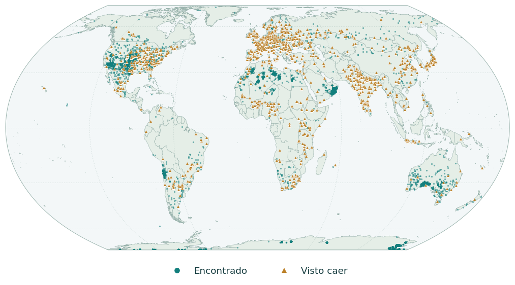

**Interpretación.** Se pueden ubicar 32,186 de 45,715 registros terrestres (70.4 %). Los encontrados representan 97.6 % del catálogo terrestre. La superposición de puntos puede ocultar concentraciones. Este mapa describe ubicaciones registradas, no tasas de caída ni riesgo de impacto; los casos sin coordenadas no desaparecen de los otros análisis.

```python
p1 = base.groupby("tipo_registro").agg(
    registros=("id", "size"), registros_mapeables=("coordenadas_utilizables", "sum"))
p1["cobertura_mapa_pct"] = 100 * p1["registros_mapeables"] / p1["registros"]
display(p1)
fig = mapa_mundial(geografia)
guardar_grafico(fig, "01_mapa_mundial")
display(Markdown(f"**Interpretación.** Se pueden ubicar {len(geografia):,} de {len(base):,} registros terrestres "
                 f"({100 * len(geografia) / len(base):.1f} %). Los encontrados representan "
                 f"{100 * base['fall'].eq('Found').mean():.1f} % del catálogo terrestre. "
                 "La superposición de puntos puede ocultar concentraciones. Este mapa describe ubicaciones registradas, "
                 "no tasas de caída ni riesgo de impacto; los casos sin coordenadas no desaparecen de los otros análisis."))
```

### P2. ¿Qué proporción de los registros geolocalizados corresponde a la Antártida?

Se aproxima la región antártica mediante latitud menor que −60°. Los porcentajes por tipo se calculan **entre sus registros mapeables**. También se informa la proporción identificada sobre el catálogo terrestre completo, sin asignar región a ubicaciones desconocidas.

| region_antartica tipo_registro | Región antártica | Resto del mundo |
| --- | --- | --- |
| Encontrado | 22099 | 8991 |
| Visto caer | 0 | 1096 |

| region_antartica tipo_registro | Región antártica | Resto del mundo |
| --- | --- | --- |
| Encontrado | 71.08 | 28.92 |
| Visto caer | 0.00 | 100.00 |

| franja_latitud | registros | porcentaje |
| --- | --- | --- |
| 90–60° S | 22099 | 68.66 |
| 0–30° N | 5815 | 18.07 |
| 30–60° N | 2680 | 8.33 |
| 30–0° S | 929 | 2.89 |
| 60–30° S | 608 | 1.89 |
| 60–90° N | 55 | 0.17 |

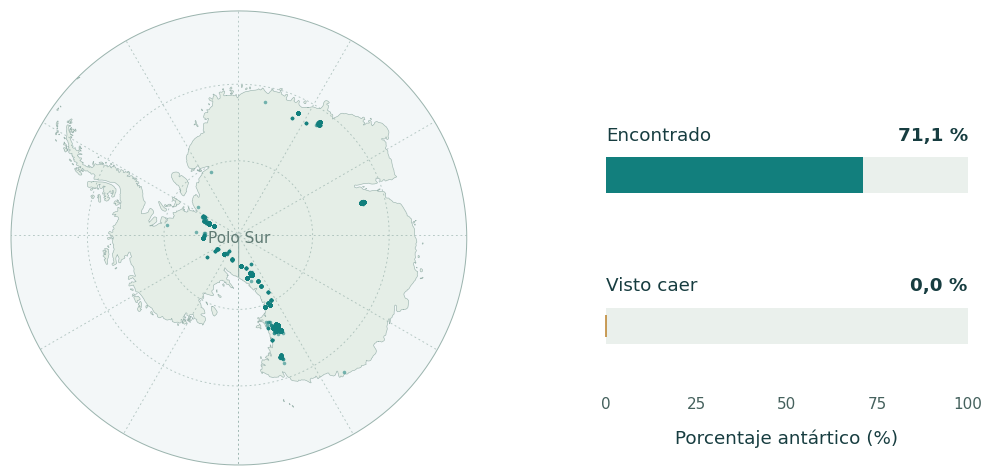

**Interpretación.** Hay 22,099 registros identificados al sur de 60° S: 68.7 % de los mapeables y 48.3 % del catálogo terrestre completo. Los dos porcentajes tienen denominadores diferentes. La región no registra caídas observadas en esta muestra; ese cero no prueba ausencia de caídas. NASA explica que el contraste con el hielo, la preservación y la concentración por el movimiento del hielo facilitan la recuperación ([NASA, 2022](https://science.nasa.gov/earth/earth-observatory/finding-meteorite-hotspots-in-antarctica-149554/)). Es contexto externo compatible con el patrón, no una causalidad estimada aquí.

```python
p2 = pd.crosstab(geografia["tipo_registro"], geografia["region_antartica"]).reindex(ORDEN)
p2_pct = p2.div(p2.sum(axis=1), axis=0) * 100
franjas = resumir_por_grupo(geografia, "franja_latitud")
display(p2)
display(p2_pct.round(2))
display(franjas[["registros", "porcentaje"]])
fig = mapa_antartida(geografia, p2_pct, len(base))
guardar_grafico(fig, "02_antartida")
n_antartida = int(geografia["lat"].lt(-60).sum())
display(Markdown(f"**Interpretación.** Hay {n_antartida:,} registros identificados al sur de 60° S: "
                 f"{100*n_antartida/len(geografia):.1f} % de los mapeables y {100*n_antartida/len(base):.1f} % "
                 "del catálogo terrestre completo. Los dos porcentajes tienen denominadores diferentes. "
                 "La región no registra caídas observadas en esta muestra; ese cero no prueba ausencia de caídas. "
                 "NASA explica que el contraste con el hielo, la preservación y la concentración por el movimiento del hielo "
                 "facilitan la recuperación ([NASA, 2022](https://science.nasa.gov/earth/earth-observatory/finding-meteorite-hotspots-in-antarctica-149554/)). "
                 "Es contexto externo compatible con el patrón, no una causalidad estimada aquí."))
```

### P3. ¿Cómo evolucionan los registros por década y tipo de descubrimiento?

El año se conserva como periodo anual. La tabla completa incluye los registros antiguos; el gráfico comienza en 1800 para hacer legibles las décadas modernas. Se muestran dos paneles con escalas verticales distintas: deben compararse las cifras, no las alturas entre paneles. La década de 2010 está incompleta.

| tipo_registro decada | Encontrado | Visto caer |
| --- | --- | --- |
| 1900 | 83 | 56 |
| 1910 | 88 | 66 |
| 1920 | 89 | 70 |
| 1930 | 218 | 91 |
| 1940 | 138 | 58 |
| 1950 | 152 | 60 |
| 1960 | 335 | 62 |
| 1970 | 4909 | 60 |
| 1980 | 6766 | 56 |
| 1990 | 11563 | 56 |
| 2000 | 17697 | 59 |
| 2010 | 1950 | 13 |

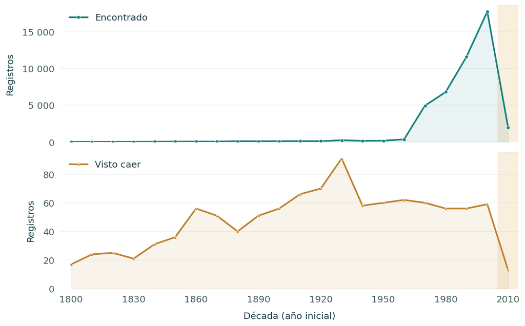

**Interpretación.** La década con más registros desde 1800 es 2000, con 17,756. Se omiten del gráfico 60 registros anteriores a 1800, conservados en la tabla completa. El último año utilizable observado es 2013; esto no garantiza que su cobertura sea completa. El crecimiento de hallazgos no implica más impactos: el año de hallazgo puede ser muy posterior a la caída. La disminución de la última década no es comparable con décadas de diez años.

```python
p3_larga = tiempo.groupby(["decada", "tipo_registro"]).agg(registros=("id", "size")).reset_index()
p3 = p3_larga.pivot_table(index="decada", columns="tipo_registro", values="registros", fill_value=0).astype(int)
ultimo_anio = int(tiempo["anio"].max())
decadas = np.arange(1800, (ultimo_anio // 10) * 10 + 1, 10)
p3_grafico = p3.reindex(decadas, fill_value=0)
display(p3_grafico.tail(12))
fig, axes = plt.subplots(2, 1, figsize=(9.4, 5.8), sharex=True, layout="constrained")
for ax, tipo, marcador in zip(axes, ORDEN, ["o", "^"]):
    y = p3_grafico[tipo].to_numpy()
    ax.fill_between(decadas, y, color=COLORES[tipo], alpha=0.09)
    ax.plot(decadas, y, color=COLORES[tipo], marker=marcador, markersize=4.5,
            linewidth=2.1, label=tipo, markeredgecolor="white", markeredgewidth=0.5)
    ax.set_ylabel("Registros")
    ax.set_ylim(bottom=0)
    ax.axvspan(2005, 2015, color="#F4E3C3", alpha=0.55, zorder=0)
    ax.legend(loc="upper left", fontsize=12)
    ax.grid(axis="x", visible=False)
    ax.yaxis.set_major_formatter(FuncFormatter(lambda valor, posicion: f"{valor:,.0f}".replace(",", " ")))
axes[1].set_xlabel("Década (año inicial)")
axes[1].set_xticks(list(range(1800, 2001, 30)) + [2010])
axes[1].set_xlim(1795, 2015)
guardar_grafico(fig, "03_registros_decada")
pico_decada = int(p3_grafico.sum(axis=1).idxmax())
display(Markdown(f"**Interpretación.** La década con más registros desde 1800 es {pico_decada}, "
                 f"con {int(p3_grafico.loc[pico_decada].sum()):,}. Se omiten del gráfico "
                 f"{int(tiempo['anio'].lt(1800).sum())} registros anteriores a 1800, conservados en la tabla completa. "
                 f"El último año utilizable observado es {ultimo_anio}; esto no garantiza que su cobertura sea completa. "
                 "El crecimiento de hallazgos no implica más impactos: el año de hallazgo puede ser muy posterior a la caída. "
                 "La disminución de la última década no es comparable con décadas de diez años."))
```

### P4. ¿Cuáles son las clases de meteoritos más frecuentes?

Se respetan las clases originales, sin fusionarlas arbitrariamente. El gráfico presenta las diez primeras; la tabla exportada contiene todas. Los porcentajes usan el total terrestre.

| class | registros | masas_positivas | masa_mediana_g | masa_media_g | porcentaje |
| --- | --- | --- | --- | --- | --- |
| L6 | 8339 | 8333 | 35.37 | 1,441.24 | 18.24 |
| H5 | 7164 | 7160 | 24.66 | 2,161.99 | 15.67 |
| L5 | 4817 | 4815 | 31.81 | 1,789.57 | 10.54 |
| H6 | 4529 | 4528 | 18.95 | 862.18 | 9.91 |
| H4 | 4222 | 4222 | 18.40 | 994.84 | 9.24 |
| LL5 | 2766 | 2766 | 16.20 | 464.68 | 6.05 |
| LL6 | 2045 | 2045 | 30.80 | 691.30 | 4.47 |
| L4 | 1256 | 1256 | 69.65 | 1,632.13 | 2.75 |
| H4/5 | 428 | 428 | 10.69 | 1,601.56 | 0.94 |
| CM2 | 416 | 414 | 9.45 | 368.38 | 0.91 |

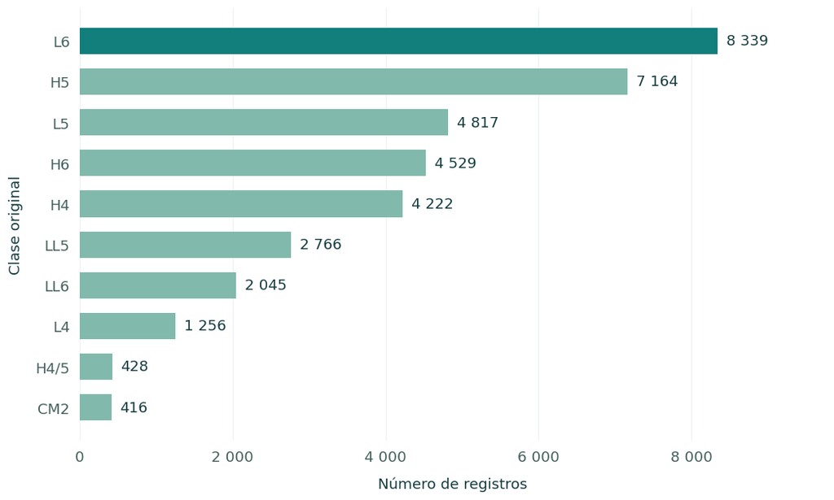

**Interpretación.** La clase más frecuente es **L6**, con 8,339 registros (18.2 %). Las diez primeras reúnen 78.7 % del catálogo terrestre. Estos porcentajes describen la composición registrada; no estiman la composición de todos los objetos que llegan a la Tierra.

```python
p4 = resumir_por_grupo(base, "class")
display(p4.head(10))
top_clases = p4.head(10).sort_values("registros")
fig, ax = plt.subplots(figsize=(9.4, 5.6), layout="constrained")
colores = ["#82B9AD"] * (len(top_clases)-1) + ["#127F7D"]
barras = ax.barh(top_clases.index, top_clases["registros"], color=colores, height=0.65)
ax.bar_label(barras, labels=[f"{v:,.0f}".replace(",", " ") for v in top_clases["registros"]],
             padding=7, fontsize=12, color="#173D40")
ax.set(xlabel="Número de registros", ylabel="Clase original",
        xlim=(0, top_clases["registros"].max()*1.17))
ax.xaxis.set_major_formatter(FuncFormatter(lambda valor, posicion: f"{valor:,.0f}".replace(",", " ")))
ax.grid(axis="y", visible=False)
guardar_grafico(fig, "04_clases_frecuentes")
display(Markdown(f"**Interpretación.** La clase más frecuente es **{p4.index[0]}**, con "
                 f"{int(p4.iloc[0]['registros']):,} registros ({p4.iloc[0]['porcentaje']:.1f} %). "
                 f"Las diez primeras reúnen {p4.head(10)['porcentaje'].sum():.1f} % del catálogo terrestre. "
                 "Estos porcentajes describen la composición registrada; no estiman la composición de todos los objetos que llegan a la Tierra."))
```

### P5. ¿Cómo se distribuyen las masas registradas?

El histograma utiliza `np.log10` de las masas estrictamente positivas. Los límites de los intervalos y sus frecuencias se exportan a Excel. Una unidad horizontal equivale a multiplicar la masa por diez.

|  | valor | unidad |
| --- | --- | --- |
| Registros | 45,566.00 | registros |
| Media | 13,283.62 | g |
| Desviación estándar | 575,108.68 | g |
| Mínimo | 0.01 | g |
| Percentil 25 | 7.20 | g |
| Mediana | 32.70 | g |
| Percentil 75 | 202.80 | g |
| Percentil 90 | 1,110.30 | g |
| Percentil 99 | 50,600.00 | g |
| Máximo | 60,000,000.00 | g |

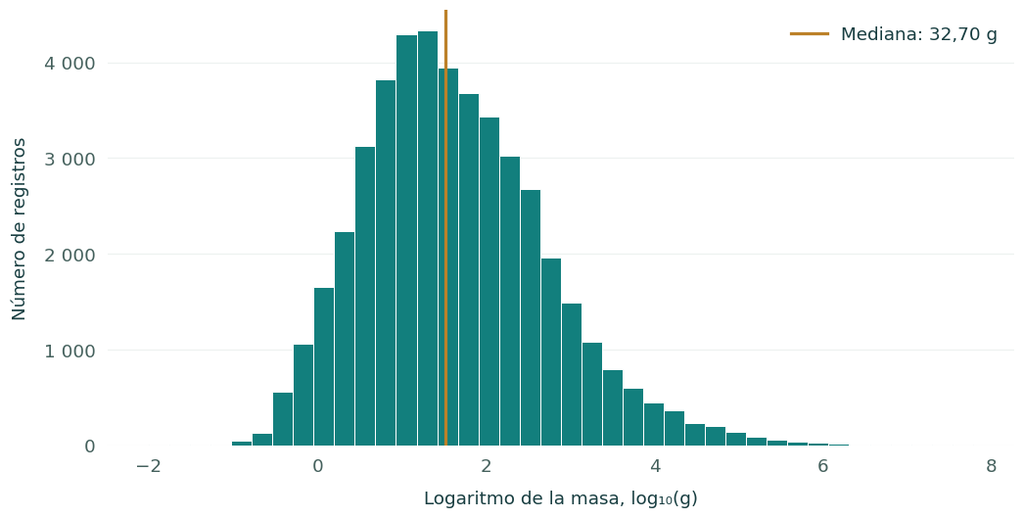

**Interpretación.** La mediana es 32.70 g y la media 13,283.62 g. La diferencia refleja una distribución muy asimétrica, con unos pocos registros de gran masa. La transformación permite observar varios órdenes de magnitud. Se excluyen solo de este análisis 149 registros con masa no positiva o ausente; no se les asigna masa cero.

```python
frecuencias, limites = np.histogram(masas["log10_masa_g"], bins=40)
p5 = pd.DataFrame({"log10_desde": limites[:-1], "log10_hasta": limites[1:], "registros": frecuencias})
estadisticas_masa = masas["mass"].describe(percentiles=[0.25, 0.5, 0.75, 0.9, 0.99]).to_frame("valor")
estadisticas_masa.index = ["Registros", "Media", "Desviación estándar", "Mínimo",
                           "Percentil 25", "Mediana", "Percentil 75", "Percentil 90", "Percentil 99", "Máximo"]
estadisticas_masa["unidad"] = ["registros"] + ["g"] * 9
display(estadisticas_masa)
fig, ax = plt.subplots(figsize=(9.4, 4.7), layout="constrained")
ax.hist(masas["log10_masa_g"], bins=limites, color="#127F7D", edgecolor="white", linewidth=0.65)
mediana_masa = masas["mass"].median()
ax.axvline(np.log10(mediana_masa), color="#BC8129", lw=2.1,
           label="Mediana: " + f"{mediana_masa:.2f}".replace(".", ",") + " g")
ax.set(xlabel="Logaritmo de la masa, log₁₀(g)", ylabel="Número de registros")
ax.set_xticks([-2, 0, 2, 4, 6, 8])
ax.yaxis.set_major_formatter(FuncFormatter(lambda valor, posicion: f"{valor:,.0f}".replace(",", " ")))
ax.grid(axis="x", visible=False)
ax.legend(loc="upper right", fontsize=12)
guardar_grafico(fig, "05_histograma_masas")
display(Markdown(f"**Interpretación.** La mediana es {mediana_masa:,.2f} g y la media "
                 f"{masas['mass'].mean():,.2f} g. La diferencia refleja una distribución muy asimétrica, "
                 "con unos pocos registros de gran masa. La transformación permite observar varios órdenes de magnitud. "
                 f"Se excluyen solo de este análisis {len(base)-len(masas):,} registros con masa no positiva o ausente; no se les asigna masa cero."))
```

### P6. ¿Cómo difieren las masas entre encontrados y vistos caer?

Las cajas se calculan sobre masa en gramos: mediana, cuartiles y bigotes de 1,5 veces el rango intercuartílico. El eje vertical se muestra en escala logarítmica. Se mantienen y dibujan los valores extremos.

| tipo_registro | registros | masas_positivas | masa_mediana_g | masa_media_g | porcentaje | p25_g | p75_g |
| --- | --- | --- | --- | --- | --- | --- | --- |
| Encontrado | 44491 | 44491 | 30.54 | 12,467.24 | 97.64 | 6.97 | 178.35 |
| Visto caer | 1075 | 1075 | 2,800.00 | 47,070.72 | 2.36 | 686.00 | 10,450.00 |

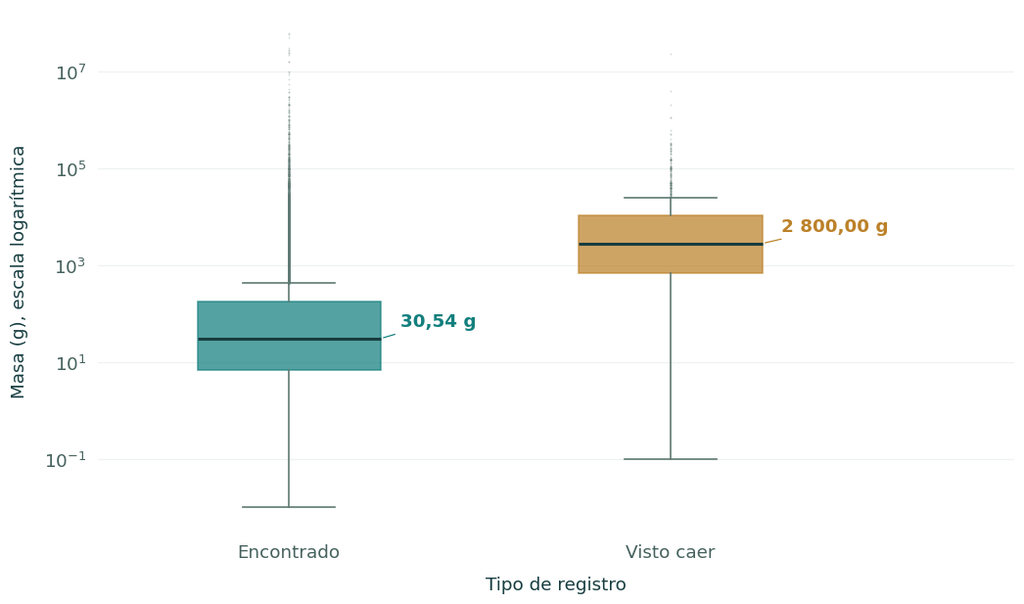

**Interpretación.** La mediana de los vistos caer es 2,800.00 g; la de los encontrados, 30.54 g. La razón es 91.7. Es una diferencia descriptiva entre grupos seleccionados por mecanismos de observación y recuperación distintos. No demuestra que observar la caída cause una masa mayor.

```python
p6 = resumir_por_grupo(masas, "tipo_registro").reindex(ORDEN)
p6["p25_g"] = masas.groupby("tipo_registro")["mass"].quantile(0.25)
p6["p75_g"] = masas.groupby("tipo_registro")["mass"].quantile(0.75)
display(p6)
fig, ax = plt.subplots(figsize=(9.4, 5.5), layout="constrained")
cajas = ax.boxplot([masas.loc[masas["tipo_registro"].eq(tipo), "mass"] for tipo in ORDEN],
                  tick_labels=ORDEN, patch_artist=True, widths=0.48,
                  flierprops={"marker": ".", "markersize": 2.4, "alpha": 0.28, "markeredgewidth": 0, "markerfacecolor": "#607B74"},
                  medianprops={"color": "#173D40", "linewidth": 2.0},
                  whiskerprops={"color": "#607B74", "linewidth": 1.1},
                  capprops={"color": "#607B74", "linewidth": 1.1})
for caja, tipo in zip(cajas["boxes"], ORDEN):
    caja.set_facecolor(COLORES[tipo])
    caja.set_edgecolor(COLORES[tipo])
    caja.set_alpha(0.72)
for posicion, tipo in enumerate(ORDEN, start=1):
    mediana = p6.loc[tipo, "masa_mediana_g"]
    etiqueta = f"{mediana:,.2f}".replace(",", " ").replace(".", ",") + " g"
    ax.annotate(etiqueta, (posicion+0.24, mediana), xytext=(13, 8),
                textcoords="offset points", fontsize=12, weight="bold", color=COLORES[tipo],
                arrowprops={"arrowstyle": "-", "color": COLORES[tipo], "lw": 0.8})
ax.set_yscale("log")
ax.set(xlabel="Tipo de registro", ylabel="Masa (g), escala logarítmica", xlim=(0.5, 2.9))
ax.grid(axis="x", visible=False)
guardar_grafico(fig, "06_cajas_masa_tipo")
razon_medianas = p6.loc["Visto caer", "masa_mediana_g"] / p6.loc["Encontrado", "masa_mediana_g"]
display(Markdown(f"**Interpretación.** La mediana de los vistos caer es "
                 f"{p6.loc['Visto caer', 'masa_mediana_g']:,.2f} g; la de los encontrados, "
                 f"{p6.loc['Encontrado', 'masa_mediana_g']:,.2f} g. La razón es {razon_medianas:.1f}. "
                 "Es una diferencia descriptiva entre grupos seleccionados por mecanismos de observación y recuperación distintos. "
                 "No demuestra que observar la caída cause una masa mayor."))
```

### P7. ¿Cuáles son los diez meteoritos más pesados?

Se usa `nlargest` sobre la masa positiva registrada. Las toneladas del gráfico son gramos divididos entre un millón; la tabla conserva gramos y kilogramos.

|  | id | name | class | tipo_registro | anio | mass | masa_kg | masa_t |
| --- | --- | --- | --- | --- | --- | --- | --- | --- |
| 16392 | 11890 | Hoba | Iron, IVB | Encontrado | 1920 | 60,000,000.00 | 60,000.00 | 60.00 |
| 5373 | 5262 | Cape York | Iron, IIIAB | Encontrado | 1818 | 58,200,000.00 | 58,200.00 | 58.20 |
| 5365 | 5247 | Campo del Cielo | Iron, IAB-MG | Encontrado | 1575 | 50,000,000.00 | 50,000.00 | 50.00 |
| 5370 | 5257 | Canyon Diablo | Iron, IAB-MG | Encontrado | 1891 | 30,000,000.00 | 30,000.00 | 30.00 |
| 3455 | 2335 | Armanty | Iron, IIIE | Encontrado | 1898 | 28,000,000.00 | 28,000.00 | 28.00 |
| 12613 | 10912 | Gibeon | Iron, IVA | Encontrado | 1836 | 26,000,000.00 | 26,000.00 | 26.00 |
| 5468 | 5363 | Chupaderos | Iron, IIIAB | Encontrado | 1852 | 24,300,000.00 | 24,300.00 | 24.30 |
| 26297 | 16852 | Mundrabilla | Iron, IAB-ung | Encontrado | 1911 | 24,000,000.00 | 24,000.00 | 24.00 |
| 920 | 23593 | Sikhote-Alin | Iron, IIAB | Visto caer | 1947 | 23,000,000.00 | 23,000.00 | 23.00 |
| 5016 | 4919 | Bacubirito | Iron, ungrouped | Encontrado | 1863 | 22,000,000.00 | 22,000.00 | 22.00 |

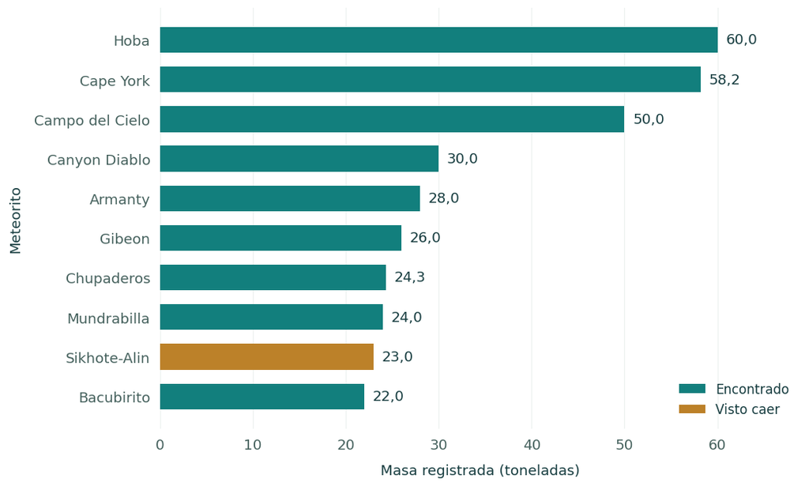

**Interpretación.** Hoba encabeza el catálogo con 60 toneladas registradas. Estos diez registros suman 57.1 % de la masa positiva registrada. No son una muestra representativa del tamaño típico ni una estimación de energía de impacto.

```python
p7 = masas.nlargest(10, "mass")[["id", "name", "class", "tipo_registro", "anio", "mass", "masa_kg"]].copy()
p7["masa_t"] = p7["mass"] / 1_000_000
display(p7)
orden_masas = p7.sort_values("mass")
fig, ax = plt.subplots(figsize=(9.4, 5.6), layout="constrained")
colores = orden_masas["tipo_registro"].map(COLORES).tolist()
barras = ax.barh(orden_masas["name"], orden_masas["masa_t"], color=colores, height=0.65)
ax.bar_label(barras, labels=[f"{v:.1f}".replace(".", ",") for v in orden_masas["masa_t"]],
             padding=7, fontsize=12)
ax.set(xlabel="Masa registrada (toneladas)", ylabel="Meteorito",
        xlim=(0, p7["masa_t"].max()*1.15))
ax.grid(axis="y", visible=False)
from matplotlib.patches import Patch
ax.legend(handles=[Patch(facecolor=COLORES[t], label=t) for t in ORDEN],
           loc="lower right", fontsize=11)
guardar_grafico(fig, "07_mas_pesados")
display(Markdown(f"**Interpretación.** {p7.iloc[0]['name']} encabeza el catálogo con "
                 f"{p7.iloc[0]['masa_t']:.0f} toneladas registradas. Estos diez registros suman "
                 f"{100*p7['mass'].sum()/masas['mass'].sum():.1f} % de la masa positiva registrada. "
                 "No son una muestra representativa del tamaño típico ni una estimación de energía de impacto."))
```

### P8. ¿Qué relación descriptiva existe entre año registrado y masa?

Se estudian registros desde 1800 con año y masa positiva, sin exigir coordenadas. Los paneles usan los mismos límites y muestran cada tipo por separado para reducir superposición. Se informa la correlación de rangos de Spearman como descripción, sin pruebas causales.

|  | tipo_registro | registros | rho_spearman |
| --- | --- | --- | --- |
| 0 | Encontrado | 44203 | 0.05 |
| 1 | Visto caer | 1040 | 0.03 |

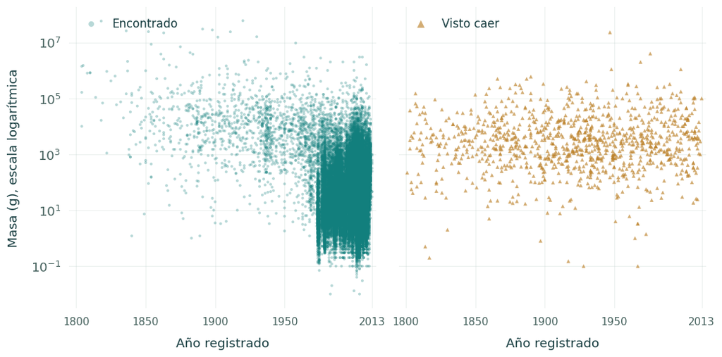

**Interpretación.** Las correlaciones de rangos son 0.049 para encontrados y 0.026 para vistos caer, ambas próximas a cero. El gráfico muestra gran dispersión: el año no presenta una asociación monótona fuerte con la masa dentro de estos grupos. Los cambios en los objetos buscados y registrados pueden alterar su composición. Estos coeficientes no descartan relaciones no lineales ni permiten interpretar causalidad. No se ajusta una tendencia común que mezcle ambos grupos.

```python
p8_datos = masas[masas["anio"].notna() & masas["anio"].ge(1800)].copy()
filas = []

fig, axes = plt.subplots(1, 2, figsize=(9.4, 4.6), sharex=True, sharey=True, layout="constrained")
for ax, tipo, marcador in zip(axes, ORDEN, ["o", "^"]):
    grupo = p8_datos[p8_datos["tipo_registro"] == tipo]
    # Spearman = correlación de Pearson entre rangos, sin otra dependencia.
    rho = grupo["anio"].rank().corr(grupo["mass"].rank())
    filas.append({"tipo_registro": tipo, "registros": len(grupo), "rho_spearman": rho})
    ax.scatter(grupo["anio"], grupo["mass"], s=7 if tipo == "Encontrado" else 13,
               marker=marcador, alpha=0.30 if tipo == "Encontrado" else 0.65,
               color=COLORES[tipo], edgecolors="none", label=tipo)
    ax.set_yscale("log")
    ax.set(xlabel="Año registrado", xlim=(1795, ultimo_anio+3))
    ax.set_xticks([1800, 1850, 1900, 1950, ultimo_anio])
    ax.tick_params(axis="x", labelsize=10)
    ax.legend(loc="upper left", fontsize=11, markerscale=2)
axes[0].set_ylabel("Masa (g), escala logarítmica")
p8 = pd.DataFrame(filas)
display(p8)
guardar_grafico(fig, "08_anio_masa")
display(Markdown(f"**Interpretación.** Las correlaciones de rangos son {p8.iloc[0]['rho_spearman']:.3f} para encontrados y "
                 f"{p8.iloc[1]['rho_spearman']:.3f} para vistos caer, ambas próximas a cero. "
                 "El gráfico muestra gran dispersión: el año no presenta una asociación monótona fuerte con la masa dentro de estos grupos. "
                 "Los cambios en los objetos buscados y registrados pueden alterar su composición. Estos coeficientes no descartan "
                 "relaciones no lineales ni permiten interpretar causalidad. No se ajusta una tendencia común que mezcle ambos grupos."))
```

### P9. ¿Cómo cambia la composición de clases entre décadas?

Se muestran las ocho clases más frecuentes del periodo 1900–2013 y una categoría «Otras clases». Se fija el mismo conjunto de clases para todas las décadas. Cada columna suma 100 % de los registros de esa década; se exportan tanto conteos como porcentajes. La década de 2010 es incompleta.

| decada clase_grafico | 1900 | 1910 | 1920 | 1930 | 1940 | 1950 | 1960 | 1970 | 1980 | 1990 | 2000 | 2010 |
| --- | --- | --- | --- | --- | --- | --- | --- | --- | --- | --- | --- | --- |
| L6 | 15.80 | 17.50 | 16.40 | 15.90 | 17.90 | 14.20 | 14.60 | 14.90 | 19.60 | 23.60 | 15.70 | 16.40 |
| H5 | 9.40 | 7.80 | 12.60 | 11.30 | 14.30 | 14.20 | 17.40 | 18.20 | 24.40 | 15.50 | 12.80 | 10.60 |
| L5 | 6.50 | 5.20 | 3.80 | 5.50 | 5.60 | 5.70 | 6.00 | 1.90 | 3.20 | 9.60 | 17.40 | 7.50 |
| H6 | 2.90 | 3.20 | 2.50 | 7.10 | 6.60 | 4.20 | 6.80 | 10.80 | 10.70 | 10.40 | 9.70 | 9.50 |
| H4 | 4.30 | 6.50 | 4.40 | 11.00 | 5.10 | 7.50 | 9.80 | 17.50 | 18.90 | 7.30 | 5.10 | 7.90 |
| LL5 | 0.00 | 1.30 | 0.60 | 1.00 | 1.00 | 0.00 | 1.30 | 0.30 | 0.40 | 13.00 | 6.30 | 4.30 |
| LL6 | 2.20 | 0.60 | 1.90 | 2.60 | 1.50 | 1.40 | 1.50 | 4.40 | 2.60 | 2.40 | 6.60 | 7.40 |
| L4 | 0.00 | 2.60 | 3.10 | 1.60 | 4.10 | 1.90 | 4.50 | 3.10 | 2.30 | 2.00 | 3.20 | 3.10 |
| Otras clases | 59.00 | 55.20 | 54.70 | 44.00 | 43.90 | 50.90 | 38.00 | 28.90 | 18.00 | 16.30 | 23.30 | 33.30 |

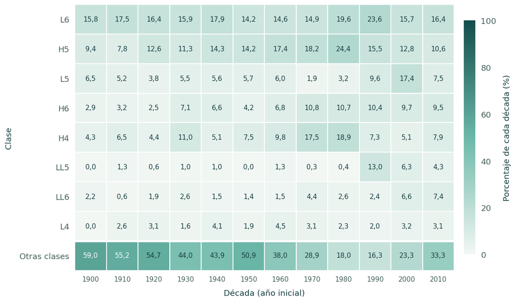

**Interpretación.** Entre las ocho clases destacadas, L5 presenta el mayor cambio absoluto entre 1970 y 2000: pasa de 1.9 % a 17.4 % (+15.5 puntos porcentuales). La normalización permite comparar composición sin confundirla con el aumento del número de registros. «Otras clases» reúne categorías diferentes: no es una clase científica. Los cambios pueden depender de las regiones y campañas representadas, por lo que no se atribuyen a un cambio físico del material que llega a la Tierra.

|  | clase_grafico | decada | porcentaje |
| --- | --- | --- | --- |
| 0 | L6 | 1900 | 15.83 |
| 1 | H5 | 1900 | 9.35 |
| 2 | L5 | 1900 | 6.47 |
| 3 | H6 | 1900 | 2.88 |
| 4 | H4 | 1900 | 4.32 |

```python
p9_datos = tiempo[tiempo["anio"].ge(1900)].copy()
clases_principales = p9_datos["class"].value_counts().head(8).index.tolist()
p9_datos["clase_grafico"] = p9_datos["class"].where(p9_datos["class"].isin(clases_principales), "Otras clases")
p9_conteos = pd.crosstab(p9_datos["clase_grafico"], p9_datos["decada"]).reindex(clases_principales + ["Otras clases"])
p9_pct = p9_conteos.div(p9_conteos.sum(axis=0), axis=1) * 100
display(p9_pct.round(1))
fig, ax = plt.subplots(figsize=(10.5, 6.1), layout="constrained")
from matplotlib.colors import LinearSegmentedColormap
mapa_color = LinearSegmentedColormap.from_list("meteoritos", ["#F3F7F4", "#6BB8A8", "#134C4B"])
imagen = ax.imshow(p9_pct, cmap=mapa_color, vmin=0, vmax=100, aspect="auto")
ax.set_xticks(range(len(p9_pct.columns)), [str(int(d)) for d in p9_pct.columns])
ax.set_yticks(range(len(p9_pct.index)), p9_pct.index)
ax.tick_params(axis="x", labelsize=10)
for fila in range(p9_pct.shape[0]):
    for columna in range(p9_pct.shape[1]):
        valor = p9_pct.iloc[fila, columna]
        ax.text(columna, fila, f"{valor:.1f}".replace(".", ","), ha="center", va="center", fontsize=10,
                color="white" if valor > 55 else "#173D40")
ax.set(xlabel="Década (año inicial)", ylabel="Clase")
ax.grid(False)
# Separaciones blancas delimitan las celdas; una línea distingue la categoría residual.
ax.set_xticks(np.arange(-0.5, len(p9_pct.columns), 1), minor=True)
ax.set_yticks(np.arange(-0.5, len(p9_pct.index), 1), minor=True)
ax.grid(which="minor", color="white", linewidth=1.4, alpha=1)
ax.tick_params(which="minor", bottom=False, left=False)
ax.axhline(7.5, color="white", lw=3)
barra_color = fig.colorbar(imagen, ax=ax, label="Porcentaje de cada década (%)", shrink=0.88, pad=0.025)
barra_color.outline.set_visible(False)
guardar_grafico(fig, "09_clases_decadas")
cambio_clases = (p9_pct[2000] - p9_pct[1970]).drop("Otras clases")
clase_cambio = cambio_clases.abs().idxmax()
display(Markdown(f"**Interpretación.** Entre las ocho clases destacadas, {clase_cambio} presenta el mayor cambio absoluto "
                 f"entre 1970 y 2000: pasa de {p9_pct.loc[clase_cambio, 1970]:.1f} % a "
                 f"{p9_pct.loc[clase_cambio, 2000]:.1f} % ({cambio_clases[clase_cambio]:+.1f} puntos porcentuales). "
                 "La normalización permite comparar composición sin confundirla con el aumento del número de registros. "
                 "«Otras clases» reúne categorías diferentes: no es una clase científica. Los cambios pueden depender de las "
                 "regiones y campañas representadas, por lo que no se atribuyen a un cambio físico del material que llega a la Tierra."))
# Formato largo: una fila por clase y década, útil para exportar y comparar.
p9_largo = p9_pct.rename_axis(index="clase_grafico", columns="decada").reset_index().melt(
    id_vars="clase_grafico", var_name="decada", value_name="porcentaje")
p9_largo["decada"] = p9_largo["decada"].astype(int)
assert not p9_largo.duplicated(["clase_grafico", "decada"]).any()
reconstruida = p9_largo.pivot_table(index="clase_grafico", columns="decada", values="porcentaje")
np.testing.assert_allclose(reconstruida.reindex(index=p9_pct.index, columns=p9_pct.columns), p9_pct)
display(p9_largo.head())
```

### P10. ¿Qué registros se ubican en el Perú y qué caracteriza a Carancas?

Se selecciona una caja regional y se contrasta cada candidato con el polígono peruano. La frontera inicial 1:110 millones excluía Carancas; la versión 1:10 millones lo incluye y coincide con la fuente de Arizona State University. Se conservan ambos resultados cartográficos y la decisión analítica, sin alterar coordenadas. La muestra peruana sigue teniendo tres registros. No se pretende construir un inventario oficial actualizado ni se sustituyen valores del CSV por otras fuentes.

|  | id | name | class | mass | tipo_registro | anio | lat | long | dentro_peru_cartografia | dentro_peru_10m | peru_analisis | criterio_pais |
| --- | --- | --- | --- | --- | --- | --- | --- | --- | --- | --- | --- | --- |
| 169 | 45817 | Carancas | H4-5 | 342.00 | Visto caer | 2007 | -16.66 | -69.04 | False | True | True | Perú confirmado por Arizona State University y... |
| 228 | 51559 | Daule | L5 | 6,580.00 | Visto caer | 2008 | -1.87 | -79.96 | False | False | False | Cartografía Natural Earth 1:10m (aproximada) |
| 5442 | 44877 | Cerro La Tiza | H4 | 3,740.00 | Encontrado | 2002 | -14.53 | -75.78 | True | True | True | Cartografía Natural Earth 1:10m (aproximada) |
| 37798 | 23797 | Tambo Quemado | Iron, IIIAB | 141,000.00 | Encontrado | 1950 | -14.67 | -74.50 | True | True | True | Cartografía Natural Earth 1:10m (aproximada) |

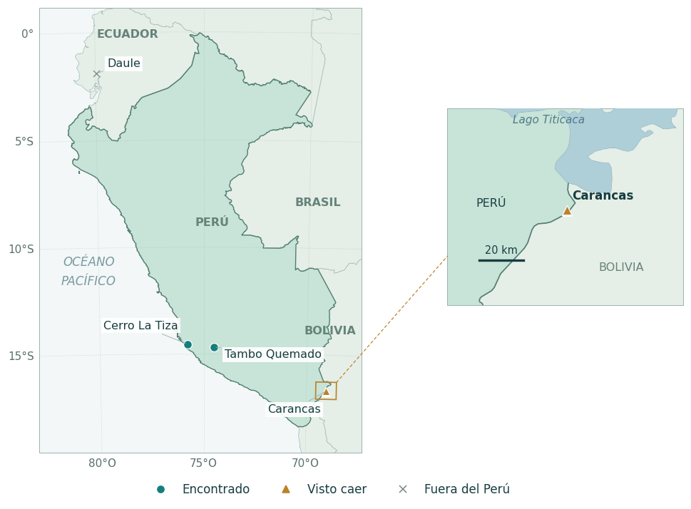

**Interpretación.** La caja contiene 4 registros, de los cuales 3 se identifican como peruanos: Carancas, Cerro La Tiza, Tambo Quemado. Daule queda fuera, por lo que no se cuenta como peruano. La clasificación de Carancas se basa en la fuente académica, y es coherente con Natural Earth 1:10m. La tabla conserva también la frontera 1:110m, que lo excluía, para auditar el cambio de escala. Carancas aparece como H4-5, visto caer en 2007, con 342 g registrados. El [Centro de Estudios de Meteoritos de Arizona State University](https://meteorites.asu.edu/meteorites/carancas) documenta la caída en Perú el 15 de septiembre de 2007 y la recuperación de más de 340 g. La masa recuperada no equivale a la masa del cuerpo que produjo el impacto. Los tres casos identificados describen este archivo histórico, no todos los meteoritos conocidos actualmente en el Perú.

```python
candidatos = geografia[geografia["lat"].between(-18.5, 0.1) & geografia["long"].between(-81.5, -68.5)].copy()
pais_peru = next(pais for pais in paises if pais["properties"]["nombre"] == "Peru")
geometria = pais_peru["geometry"]
poligonos_peru = [geometria["coordinates"]] if geometria["type"] == "Polygon" else geometria["coordinates"]
dentro = np.zeros(len(candidatos), dtype=bool)
for poligono in poligonos_peru:
    dentro |= RutaPoligono(poligono[0]).contains_points(candidatos[["long", "lat"]].to_numpy())
candidatos["dentro_peru_cartografia"] = dentro
# La versión 1:10m mejora el detalle sin borrar el diagnóstico original 1:110m.
peru_10m = next(g for nombre, g in paises_cartograficos("10m") if nombre == "Peru")
candidatos["dentro_peru_10m"] = [peru_10m.covers(Point(lon, lat))
                                for lon, lat in zip(candidatos["long"], candidatos["lat"])]
candidatos["peru_analisis"] = candidatos["dentro_peru_10m"]
candidatos["criterio_pais"] = "Cartografía Natural Earth 1:10m (aproximada)"
# La cartografía 1:10m incluye Carancas; la fuente académica confirma el país.
candidatos.loc[candidatos["id"].eq(45817), "peru_analisis"] = True
candidatos.loc[candidatos["id"].eq(45817), "criterio_pais"] = "Perú confirmado por Arizona State University y Natural Earth 1:10m"
p10 = candidatos[["id", "name", "class", "mass", "tipo_registro", "anio", "lat", "long", "dentro_peru_cartografia", "dentro_peru_10m", "peru_analisis", "criterio_pais"]].copy()
peru = candidatos[candidatos["peru_analisis"]].copy()
carancas = base.loc[base["id"].eq(45817)].iloc[0]
display(p10)
fig = mapa_peru(peru, candidatos)
guardar_grafico(fig, "10_peru_carancas")
display(Markdown(f"**Interpretación.** La caja contiene {len(candidatos)} registros, de los cuales "
                 f"{len(peru)} se identifican como peruanos: {', '.join(peru['name'])}. "
                 "Daule queda fuera, por lo que no se cuenta como peruano. La clasificación de Carancas se basa en la fuente académica, "
                 "y es coherente con Natural Earth 1:10m. La tabla conserva también la frontera 1:110m, que lo excluía, para auditar el cambio de escala. "
                 f"Carancas aparece como {carancas['class']}, visto caer en {int(carancas['anio'])}, con "
                 f"{carancas['mass']:.0f} g registrados. "
                 "El [Centro de Estudios de Meteoritos de Arizona State University](https://meteorites.asu.edu/meteorites/carancas) "
                 "documenta la caída en Perú el 15 de septiembre de 2007 y la recuperación de más de 340 g. "
                 "La masa recuperada no equivale a la masa del cuerpo que produjo el impacto. "
                 "Los tres casos identificados describen este archivo histórico, no todos los meteoritos conocidos actualmente en el Perú."))
```

## 5. Conclusiones y límites

Las siguientes conclusiones se calculan con las mismas tablas utilizadas en las figuras.

```python
conclusiones = pd.DataFrame({
    "hallazgo": ["Registros terrestres", "Cobertura geográfica (%)", "Registros antárticos identificados",
                 "Antártida entre mapeables (%)", "Masa mediana positiva (g)", "Máxima masa (t)",
                 "Registros peruanos identificados"],
    "valor": [len(base), 100*len(geografia)/len(base), n_antartida,
              100*n_antartida/len(geografia), mediana_masa, p7.iloc[0]["masa_t"], len(peru)]
})
display(conclusiones)
display(Markdown(f"El catálogo terrestre contiene **{len(base):,} registros**, dominados por hallazgos. "
                 f"La Antártida concentra **{100*n_antartida/len(geografia):.1f} %** de los registros mapeables. "
                 f"La masa mediana positiva es **{mediana_masa:,.2f} g**, muy inferior a la media, y Hoba alcanza **60 t**. "
                 "Las masas difieren entre tipos de registro y la composición del catálogo cambia entre décadas. "
                 "Estos resultados describen selección, registro y recuperación, además de características de los meteoritos."))
```

|  | hallazgo | valor |
| --- | --- | --- |
| 0 | Registros terrestres | 45,715.00 |
| 1 | Cobertura geográfica (%) | 70.41 |
| 2 | Registros antárticos identificados | 22,099.00 |
| 3 | Antártida entre mapeables (%) | 68.66 |
| 4 | Masa mediana positiva (g) | 32.70 |
| 5 | Máxima masa (t) | 60.00 |
| 6 | Registros peruanos identificados | 3.00 |

El catálogo terrestre contiene **45,715 registros**, dominados por hallazgos. La Antártida concentra **68.7 %** de los registros mapeables. La masa mediana positiva es **32.70 g**, muy inferior a la media, y Hoba alcanza **60 t**. Las masas difieren entre tipos de registro y la composición del catálogo cambia entre décadas. Estos resultados describen selección, registro y recuperación, además de características de los meteoritos.

**Limitaciones.** El catálogo no es un censo de impactos. Hay ubicaciones desconocidas y masas faltantes o cero, años antiguos con precisión anual, una observación de otro planeta y una década final incompleta. Los lugares con más registros pueden tener mayor esfuerzo de búsqueda o condiciones de conservación favorables. Los nombres e identificadores no prueban que todos los registros correspondan a impactos independientes. La cartografía tiene fronteras generalizadas. Las cifras se refieren al archivo entregado, no a un catálogo actualizado a 2026.

## 6. Comprobaciones antes de exportar

Se verifica conservación de registros, reconciliación de conteos, denominadores, cobertura de los histogramas y preservación de años históricos. Las comprobaciones no sustituyen la revisión visual de cada figura.

```python
assert len(datos) == len(original) and datos["id"].is_unique
assert len(base) + (~datos["es_terrestre"]).sum() == len(original)
assert p1["registros"].sum() == len(base)
assert p1["registros_mapeables"].sum() == len(geografia)
assert p2.to_numpy().sum() == len(geografia)
assert p3.to_numpy().sum() == len(tiempo)
assert p4["registros"].sum() == len(base)
assert p5["registros"].sum() == len(masas)
assert p6["registros"].sum() == len(masas)
assert p8["registros"].sum() == len(p8_datos)
assert p9_conteos.to_numpy().sum() == len(p9_datos)
assert np.allclose(p9_pct.sum(axis=0), 100)
assert np.isfinite(masas["log10_masa_g"]).all()
assert int(datos.loc[datos["name"].eq("Nogata"), "fecha_anual"].iloc[0].year) == 860
assert datos.loc[datos["year"].eq(2101), "anio"].isna().all()
assert set(p7["id"]) == set(base.nlargest(10, "mass")["id"])
assert set(peru["name"]) == {"Carancas", "Cerro La Tiza", "Tambo Quemado"}
print("Conteos, porcentajes, años históricos y subconjuntos reconciliados correctamente.")
```

```
Conteos, porcentajes, años históricos y subconjuntos reconciliados correctamente.
```

## 7. Exportación del CSV, las tablas y los resultados

El CSV conserva las 45.716 filas y las columnas originales, junto con las variables analíticas y banderas. `es_terrestre = False` permite identificar la exclusión de Marte. Las fechas anuales se exportan como texto de año para evitar que Excel interprete 860 como una fecha moderna.

El Excel contiene resultados estáticos reproducibles: el cálculo se realiza en Python y se regenera al ejecutar el notebook. No es un modelo con fórmulas de Excel. Los nombres de las hojas corresponden a las preguntas y se incluyen muestras, calidad, diccionario y fuentes.

```python
muestras = pd.DataFrame([
    ["P1", len(geografia), "Terrestres con coordenadas utilizables"],
    ["P2", len(geografia), "Terrestres con coordenadas utilizables; porcentajes por tipo"],
    ["P3", len(tiempo), "Año utilizable; gráfico desde 1800, tabla completa"],
    ["P4", len(base), "Todos los terrestres; gráfico de diez clases"],
    ["P5", len(masas), "Terrestres con masa positiva"],
    ["P6", len(masas), "Terrestres con masa positiva"],
    ["P7", len(p7), "Diez mayores masas entre todas las masas positivas"],
    ["P8", len(p8_datos), "Masa positiva y año desde 1800"],
    ["P9", len(p9_datos), "Año desde 1900; porcentaje dentro de cada década"],
    ["P10", len(peru), "Cartografía más confirmación documental de Carancas; candidatos en P10"]
], columns=["pregunta", "registros_analizados", "criterio"])
fuentes = pd.DataFrame([
    ["Datos originales", "datos_originales/meteorites.csv", "Archivo entregado por el profesor; principal fuente de cifras"],
    ["Diccionario original", "datos_originales/_diccionario_de_datos.csv", "Tipos, nulos y ejemplos originales"],
    ["TidyTuesday", "https://github.com/rfordatascience/tidytuesday/tree/main/data/2019/2019-06-11", "Procedencia y masa en gramos; README incluido en recursos"],
    ["NASA NTRS", "https://ntrs.nasa.gov/citations/20100003417", "Meridiani Planum fue encontrado en Marte"],
    ["NASA Earth Observatory", "https://science.nasa.gov/earth/earth-observatory/finding-meteorite-hotspots-in-antarctica-149554/", "Contexto sobre preservación, hielo y búsqueda en Antártida"],
    ["Arizona State University", "https://meteorites.asu.edu/meteorites/carancas", "Carancas: caída observada en Perú y masa recuperada"],
    ["Natural Earth", "https://www.naturalearthdata.com/downloads/110m-cultural-vectors/110m-admin-0-countries/", "Fronteras de referencia; dominio público"],
    ["Natural Earth GeoJSON", "https://github.com/nvkelso/natural-earth-vector/blob/master/geojson/ne_110m_admin_0_countries.geojson", "Copia local reducida a nombre y geometría, consulta 2026-11-12"]
], columns=["fuente", "ubicacion", "uso"])
exportacion = datos.copy()
exportacion["fecha_anual"] = datos["fecha_anual"].astype("string").where(datos["fecha_anual"].notna(), "")
exportacion.to_csv(SALIDA / "meteoritos_preparados.csv", index=False, encoding="utf-8-sig")

# Diccionario de todas las variables finales, incluidas las derivadas.
descripciones = {
    "name": "Nombre original del meteorito", "id": "Identificador único del registro",
    "name_type": "Categoría original del nombre, conservada sin reclasificación",
    "class": "Clasificación original", "mass": "Masa original registrada (gramos)",
    "fall": "Found: hallazgo; Fell: caída observada", "year": "Año original registrado",
    "lat": "Latitud original en grados", "long": "Longitud original en grados",
    "geolocation": "Texto original de coordenadas; para análisis se usan lat y long",
    "es_terrestre": "False solo para Meridiani Planum (id 32789), encontrado en Marte",
    "estado_coordenadas": "Ausentes, ambas cero, fuera de rango o utilizables",
    "coordenadas_utilizables": "Coordenadas presentes, en rango y distintas de (0,0)",
    "masa_positiva": "Masa estrictamente mayor que cero",
    "masa_kg": "Masa original en gramos dividida entre 1000",
    "log10_masa_g": "Logaritmo base diez de masa positiva en gramos; vacío en otros casos",
    "anio": "Año entero entre 1 y 2026; vacío si ausente o inválido",
    "fecha_anual": "Periodo anual; se exporta como texto y no inventa día ni mes",
    "decada": "Década del año utilizable, expresada por su año inicial",
    "tipo_registro": "Etiqueta española de fall", "franja_latitud": "Franja de 30 grados con pd.cut; solo coordenadas utilizables",
    "region_antartica": "Antártida si latitud < -60; resto si no; vacío sin coordenadas utilizables"
}
diccionario = pd.DataFrame({"variable": datos.columns,
    "tipo_python": datos.dtypes.astype(str).values,
    "descripcion": [descripciones[c] for c in datos.columns],
    "nulos": datos.isna().sum().values})
diccionario.to_csv(SALIDA / "diccionario_preparados.csv", index=False, encoding="utf-8-sig")
```

```python
from openpyxl.styles import Font, PatternFill, Alignment
from openpyxl.utils import get_column_letter

# Un único ExcelWriter reúne todas las tablas en un archivo.
hojas = {
    "Resumen": conclusiones,
    "Muestras": muestras,
    "P1_tipo_y_mapa": p1.reset_index(),
    "P2_antartida_conteos": p2.reset_index(),
    "P2_antartida_pct": p2_pct.reset_index(),
    "P2_franjas": franjas.reset_index(),
    "P3_decadas": p3.reset_index(),
    "P4_clases": p4.reset_index(),
    "P5_histograma": p5,
    "P5_estadisticas": estadisticas_masa.rename_axis("estadistica").reset_index(),
    "P6_masa_por_tipo": p6.reset_index(),
    "P7_mayores_masas": p7,
    "P8_asociacion": p8,
    "P9_clases_conteos": p9_conteos.reset_index(),
    "P9_clases_pct": p9_pct.reset_index(),
    "P10_peru_candidatos": p10,
    "Calidad": calidad,
    "Diccionario": diccionario,
    "Fuentes": fuentes,
    "Base_preparada": exportacion,
}
archivo_excel = SALIDA / "Resultados_Meteoritos.xlsx"
with pd.ExcelWriter(archivo_excel, engine="openpyxl") as escritor:
    for nombre, tabla in hojas.items():
        tabla.to_excel(escritor, sheet_name=nombre, index=False)
        hoja = escritor.sheets[nombre]
        hoja.freeze_panes = "B2" if nombre == "Base_preparada" else "A2"
        hoja.auto_filter.ref = hoja.dimensions
        hoja.sheet_view.showGridLines = False
        hoja.row_dimensions[1].height = 34
        for celda in hoja[1]:
            celda.font = Font(name="Arial", size=10, bold=True, color="FFFFFF")
            celda.fill = PatternFill("solid", fgColor="244A64")
            celda.alignment = Alignment(horizontal="center", vertical="center", wrap_text=True)
        for numero, columna in enumerate(tabla.columns, start=1):
            # Solo se examina una muestra para ajustar tablas de muchas filas.
            longitud = max([len(str(columna))] + tabla[columna].head(100).astype(str).str.len().tolist())
            hoja.column_dimensions[get_column_letter(numero)].width = min(max(longitud+3, 14), 60)
        if nombre != "Base_preparada":
            for fila in hoja.iter_rows(min_row=2):
                for celda in fila:
                    celda.font = Font(name="Arial", size=10)
                    celda.alignment = Alignment(vertical="center", wrap_text=True)
                    if isinstance(celda.value, (int, float)) and not isinstance(celda.value, bool):
                        encabezado = str(tabla.columns[celda.column-1])
                        if encabezado in ["id", "anio", "decada"]:
                            celda.number_format = "0"
                        elif encabezado in ["lat", "long"]:
                            celda.number_format = "0.00000"
                        else:
                            celda.number_format = "#,##0" if float(celda.value).is_integer() else "#,##0.00"
                    if celda.row % 2 == 0:
                        celda.fill = PatternFill("solid", fgColor="F1F5F8")
                hoja.row_dimensions[fila[0].row].height = 32 if nombre in ["Muestras", "Diccionario", "P10_peru_candidatos"] else 22
        if nombre == "Fuentes":
            hoja.column_dimensions["A"].width = 28
            hoja.column_dimensions["B"].width = 72
            hoja.column_dimensions["C"].width = 65
            for numero in range(2, hoja.max_row+1):
                hoja.row_dimensions[numero].height = 58
                if str(hoja.cell(numero, 2).value).startswith("https://"):
                    hoja.cell(numero, 2).hyperlink = hoja.cell(numero, 2).value
                    hoja.cell(numero, 2).font = Font(name="Arial", size=10, color="1763A0", underline="single")
print("CSV y Excel guardados en:", SALIDA)
print("Hojas del Excel:", len(hojas))
p9_largo.to_csv(SALIDA / "P9_composicion_larga.csv", index=False)
```

```
CSV y Excel guardados en: /Users/gabrielsaco/Documents/GitHub/Meteorito/entrega_meteoritos/resultados
Hojas del Excel: 20
```

### Verificación de los archivos guardados

Se vuelve a leer el CSV y las hojas de resultados para comprobar que la exportación conservó los datos. Las cifras se guardan con su precisión completa; el formato visual no altera los valores.

```python
csv_guardado = pd.read_csv(SALIDA / "meteoritos_preparados.csv")
assert csv_guardado["id"].tolist() == original["id"].tolist()
for nombre, tabla in hojas.items():
    if nombre == "Base_preparada":
        continue  # La base completa también se conserva y comprueba en el CSV.
    leida = pd.read_excel(archivo_excel, sheet_name=nombre)
    assert leida.shape == tabla.shape, nombre
    for columna in tabla.select_dtypes(include="number").columns:
        np.testing.assert_allclose(pd.to_numeric(leida[columna]), pd.to_numeric(tabla[columna]), equal_nan=True)
assert len(list(FIGURAS.glob("*.png"))) == 10
manifiesto = {
    "fecha_revision": "2026-11-15",
    "sha256_csv_original": hashlib.sha256((DATOS / "meteorites.csv").read_bytes()).hexdigest(),
    "registros_originales": len(original), "registros_terrestres": len(base),
    "registros_mapeables": len(geografia), "registros_masa_positiva": len(masas),
    "registros_anio_utilizable": len(tiempo), "graficos": 10,
    "hojas_excel": list(hojas),
    "python": sys.version.split()[0], "pandas": pd.__version__,
    "numpy": np.__version__, "matplotlib": matplotlib.__version__,
    "cartopy": __import__("cartopy").__version__
}
(SALIDA / "verificacion.json").write_text(json.dumps(manifiesto, indent=2, ensure_ascii=False), encoding="utf-8")
print("Exportaciones verificadas. El notebook finaliza sin errores.")
leida_larga = pd.read_csv(SALIDA / "P9_composicion_larga.csv")
assert leida_larga.shape == p9_largo.shape
np.testing.assert_allclose(leida_larga["porcentaje"], p9_largo["porcentaje"])
print("Reestructuración con melt y exportación larga verificadas.")
```

```
Exportaciones verificadas. El notebook finaliza sin errores.
Reestructuración con melt y exportación larga verificadas.
```

El informe académico se entrega en LaTeX y PDF en `informe_meteoritos`. Incluye referencias verificadas, figuras y capturas del notebook y de la aplicación. La consigna original solicita Word; el formato LaTeX/PDF corresponde a la indicación posterior del autor.